# Problem Set 5

Kasper Borys and Fernando De Stefanis

Question 1 Show the expression for $V_u$ given a fixed $\lambda$.

Answer First, note that by fixing $\lambda$ the expression for $V_u$ does not include a maximization anymore, so it becomes the simple equality given by:
$$V_u = b-c(\lambda)+\lambda\frac{\rho W}{(1+r)r}+\frac{1-\lambda}{1+r}V_u$$

Moving the terms containing $V_u$ to the left, this becomes:
$$\left(1-\frac{1-\lambda}{1+r}\right) V_u = b-c(\lambda)+\lambda\frac{\rho W}{(1+r)r}$$

Note that the coefficient on $V_u$ simplifies to $\frac{r+\lambda}{1+r}$, so that we get:
$$V_u = \frac{1+r}{r+\lambda}\left(b-c(\lambda)+\lambda\frac{\rho W}{(1+r)r}\right)$$
as desired.

Question 2 Show the value of the optimal choice of $\lambda$ given $r\to 0$.

Answer We can take the expression for a fixed $\lambda$ from Question 1 and obtain a first order condition on $\lambda$. Furthermore we substitute $c(\lambda) = \frac{a}{\gamma}\lambda^{1+\gamma}$

We start with:
$$(r+\lambda)V_u = (1+r)\left(b-\frac{a}{\gamma}\lambda^{1+\gamma}+\lambda\frac{\rho W}{(1+r)r}\right)$$

Differentiating with respect to $\lambda$, we get
$$V_u = -(1+r)a\frac{1+\gamma}{\gamma}\lambda^\gamma+\frac{\rho W}{r}$$

Substituting the expression for $V_u$ that we derived in the previous section, multiplying both sides by $r+\lambda$, and distributing the multiplication by $(1+r)$, we get:
$$(1+r)b+ \left[- \frac{a}{\gamma}\lambda^{1+\gamma}(1+r) + (1+\gamma)\frac{a}{\gamma}\lambda^{1+\gamma}(1+r)\right]+r(1+r)(1+\gamma)\frac{a}{\gamma}\lambda^\gamma - \rho W = 0$$
Now we manipulate the terms in the square brackets to get:
$$(1+r)b + (1+r)a\lambda^{1+\gamma} + r(1+r)(1+\gamma)\frac{a}{\gamma}\lambda^\gamma - \rho W = 0$$

Taking the limit of $r\to 0$, we get:
$$\lim_{r\to 0}((1+r)b + (1+r)a\lambda^{1+\gamma} + r(1+r)(1+\gamma)\frac{a}{\gamma}\lambda^\gamma - \rho W) = \lim_{r\to 0}0$$
which gives us, dropping the third term in the right-hand side,
$$b+a\lambda^{1+\gamma}-\rho W = 0$$
so we solve to obtain the desired result:
$$\lim_{r\to 0}\lambda = \left(\frac{\rho W - b}{a}\right)^\frac{1}{1+\gamma}$$

Question 3 Show the value of the optimal choice of $\lambda$ given $r\to 0$.

Answer

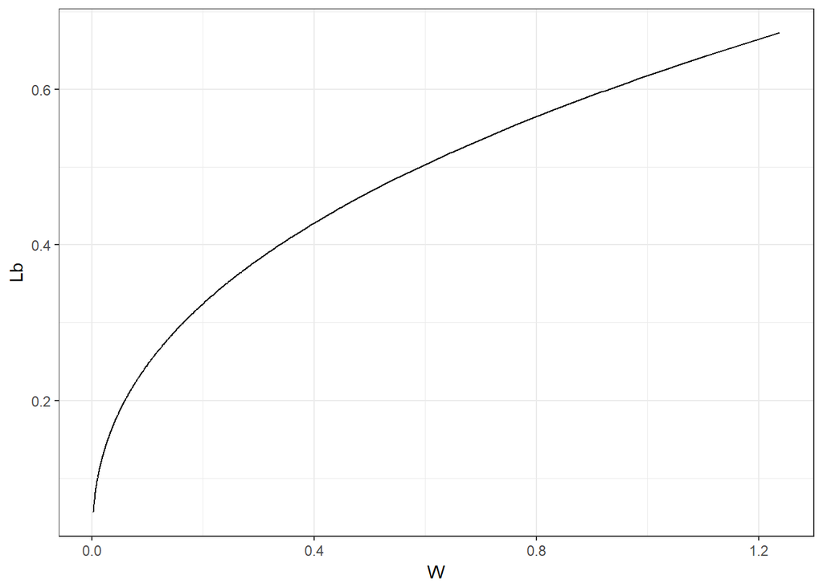

```r
p = list(rho=0.9,a = 3, gamma =1.5)
p$n = 1000
data = data.table(B = 0, W = exp(rnorm(p$n) -3))

# solve for lambda
data[, Lb := ((p$rho*W - B)/(p$a))^(1/(1+p$gamma))]
data[, Lb := pmin(pmax(Lb,0),1)]

data[, D  := rexp(p$n, rate = Lb)]

ggplot(data,aes(x=W,y=Lb)) + geom_line() + theme_bw()
```

```r
#Question 3

#W and D are data vectors
#p is a vector that contains rho, a, and gamma
#returns likelihood of D given W
lik.homo <- function(W, D, p) {
  loglik <- 0
  for (i in 1:length(D)) {
    z = (p$rho*W[i]/p$a)^(1/(1+p$gamma))
    loglik <- loglik + (log(z*exp(-1*z*D[i]))) #- log(sqrt(2*pi)*(W[i])) - (log(W[i])^2)/2)
  }
  return(loglik)
}


lik.homo(data$W,data$D,p)
```

```
## [1] -2625.884
```

```r
#construct the grid
agrid = array(seq(1,5, length = 200), dim = c(200,1))
gammagrid = array(seq(1,2, length = 200), dim = c(200,1))

mle_est <- rep(0,2)
lik_max <- -Inf
for (i in 1:length(agrid)) {
  for (j in 1:length(gammagrid)) {
    p_temp <- list(rho=0.9,a = agrid[i], gamma = gammagrid[i], n=1000)
    cur_like = lik.homo(data$W,data$D,p_temp)
    if (cur_like > lik_max) {
      lik_max = cur_like
      mle_est = list(p_temp$a,p_temp$gamma)
    }
  }
}
mle_est
```

```
## [[1]]
## [1] 4.336683
##
## [[2]]
## [1] 1.834171
```

Question 4 Find the closed form solution for $a$ given $\gamma$.

Answer We take the expression for the log-likelihood of the exponential distribution, which is given by:

$$\displaystyle\sum_{i=1}^n\left[log\left(\frac{\rho W}{a}^{\frac1{1+\gamma}}\cdot\exp\left(-\frac{\rho W}{a}^{\frac1{1+\gamma}}D_i\right)\right)\right]$$

Manipulating the logs, we obtain:

$$\displaystyle\sum_{i=1}^n\left[\frac1{1+\gamma}log\left(\frac{\rho W}{a}\right)-\frac{\rho W}{a}^{\frac1{1+\gamma}}D_i\right]$$

We differentiate this with respect to $a$ and set it equal to zero:

$$\displaystyle\sum_{i=1}^n\left[\frac1{1+\gamma}\left(-\frac1a\right)-\left(\frac1{1+\gamma}\right)\left(\frac{\rho W}{a}\right)^{\frac1{1+\gamma}-1}\left(-\frac1a\right)\left(\frac{\rho W}{a}\right)D_i\right]=0$$

With some manipulation, we get:

$$\displaystyle\left(\frac1{1+\gamma}\cdot\frac1a\right)\sum_{i=1}^n\left[\left(\frac{\rho W}{a}\right)^{\frac1{1+\gamma}}D_i-1\right]=0$$

We now get rid of the multiplicative constant outside the sum and move the one to the right hand side:

$$\displaystyle\sum_{i=1}^n\left[\left(\frac{\rho W}{a}\right)^{\frac1{1+\gamma}}D_i\right]=n$$

$$\displaystyle a^{-\frac1{1+\gamma}}\sum_{i=1}^n\left[\left(\rho W\right)^{\frac1{1+\gamma}}D_i\right]=n$$

$$\displaystyle \sum_{i=1}^n\left[\left(\rho W\right)^{\frac1{1+\gamma}}D_i\right]=na^{\frac1{1+\gamma}}$$

$$\displaystyle \left[\frac1n\sum_{i=1}^n\left(\left(\rho W\right)^{\frac1{1+\gamma}}D_i\right)\right]^{1+\gamma}=a$$

This is the desired closed-form solution.

Questions 5 and 6

AnswerFirst, the DGP.

```r
p = list(rho=0.9,a = c(1,3,5), gamma =1.5, pk=c(0.2,0.5,0.3))

p$n = 1000
data = data.table(B = 0, W = exp(rnorm(p$n) -2))

# draw the latent type
data[, k := sample.int(3,.N,prob = p$pk,replace=T)]

# solve for lambda
data[, Lb := ((p$rho*W - B)/(p$a[k]))^(1/(1+p$gamma))]
data[, Lb := pmin(pmax(Lb,0),1)] # bound it between 0 and 1

data[, D := rexp(p$n, rate = Lb)]
```

The function for the EM algorithm uses several helper functions. The first, below, is a PDF for D given W and a.

```r
#pdf for D given W and a
f <- function(w,d,p) {
  z = (p$rho*w/p$a)^(1/(1+p$gamma))
  return(z*exp(-1*z*d))
}
```

The next function is the objective function we maximize in the algorithm.

```r
#likelihood-esque function
#I'm copying this straight from Wooyong's EM pseudocode (TA session)
l <- function(W, D, pk, p) {
  res <- 0
  for (i in 1:length(W)) {
    temp <- 0
    for (k in 1:3) {
      p_temp <- list(rho = p$rho, a = p$a[[k]], gamma = p$gamma, n = p$n)
      temp <- temp + pk[[k]]*f(W[i],D[i],p_temp)
    }
    res <- res + log(temp)
  }
  return(res)
}
```

Then we have a function to estimate the parameters $a_k$, or $\theta$ depending on your preferred notation.

```r
#function that estimates a_k also known as theta in the literature
ak_est <- function(K, W, D, p, k, qik) {
  numer <- 0
  denom <- 0
  for (i in 1:p$n) {
    if (K[i] == k) {
      numer = numer + qik[[i]][[k]]*(p$rho*W[i])^(1/(1+p$gamma))*D[i]
      denom = denom + qik[[i]][[k]]
    }
  }
  res <- numer/denom
  res = res^(1+p$gamma)
  return(res)
}
```

Finally we have our actually EM function itself.

```r
EM.rando <- function(K, W, D, p, S, delta) {
  #initialize theta over iterations (in the parameters here, it's basically p)
  theta <- vector(S, mode="list")
  for (s in 1:(S+1)) {
    theta[[s]] <- rep(1,3)
  }

  #initialize probability vector over iterations
  pk <- vector(S, mode="list")
  for (s in 1:(S+1)) {
    pk[[s]] <- rep(1/3,3)
  }

  #initialize L, which will determine convergence
  L <- rep(0,S+1)
  L[1] = l(W,D,pk[[1]],list(rho=p$rho, a=theta[[1]], gamma=p$gamma, n=p$n))

  #initialize q_i(k)
  qik <- vector(p$n, mode="list")
  for (i in 1:p$n) {
    qik[[i]] <- rep(0,3)
  }


  #run the meat of the algorithm
  for (s in 1:S) {
    #E step
    for (i in 1:p$n) {
      for (k in 1:3) {
        denom <- 0
        for (kprime in 1:3) {
          denom = denom + pk[[s]][[kprime]]*f(W[i],D[i],list(rho=p$rho,a=theta[[s]][[kprime]], gamma=p$gamma))
        }
        qik[[i]][[k]] <- pk[[s]][[k]]*f(W[i],D[i],list(rho=p$rho,a=theta[[s]][[k]], gamma=p$gamma))/denom
      }
    }

    #M step
    a_temp <- rep(0,3)
    for (k in 1:3) {
      a_temp[k] = ak_est(K, W, D, p, k, qik)
    }
    theta[[s+1]] <- a_temp


    #estimate new pk which we're probably doing inefficiently due to lack of R skill
    pk_temp <- rep(0,3)
    for (k in 1:3) {
      temp <- 0
      for (i in 1:p$n) {
        temp = temp + qik[[i]][[k]]
      }
      temp = temp/p$n
      pk_temp[k] = temp
    }
    pk[[s+1]] <- pk_temp

    L[s+1] <- l(W,D,pk[[s+1]],list(rho=p$rho, a=theta[[s+1]], gamma=p$gamma, n=p$n))

    if (abs(L[s+1] - L[s]) < delta) {
      print("Improvement within tolerance")
      return(list(pk[[s+1]],theta[[s+1]],L[s+1]))
    }
  }
  print("Reached max iterations")
  return(list(pk[[S+1]],theta[[S+1]],L[s+1]))
}
```

Unfortunately, our function produces consistent but very biased results.

```r
EM.rando(data$k, data$W, data$D, p, 1000, 0.0001)
```

```
## [1] "Improvement within tolerance"
```

```
## [[1]]
## [1] 1.029611e-03 9.989403e-01 3.013827e-05
##
## [[2]]
## [1] 6.251827e-04 2.764455e+00 4.228506e+01
##
## [[3]]
## [1] -2257.008
```

By design, we can pass custom vector $p$ as a parameter to this function, which takes care of Question 6.

```r
p_custom = list(rho = 0.9, gamma = 2, n = 1000)
EM.rando(data$k, data$W, data$D, p_custom, 1000, 0.0001)
```

```
## [1] "Improvement within tolerance"
```

```
## [[1]]
## [1] 1.413842e-03 9.985429e-01 4.323903e-05
##
## [[2]]
## [1] 2.941823e-04 5.278621e+00 1.039328e+02
##
## [[3]]
## [1] -2259.065
```

Question 7

Answer We run our EM algorithm on a grid of $\gamma$ values, like earlier in this problem set, and try to find the one that maximizes likelihood as a way of recovering the true $\gamma$.

```r
#we run our function over a grid of gamma values
#to try and recover the true gamma (that maximizes likelihood)
param_est <- vector(3, mode="list")
lik_max <- -Inf
for (i in 1:length(gammagrid)) {
  p_temp <- list(rho=0.9, gamma = gammagrid[i], n=1000)
  cur_like = EM.rando(data$k, data$W, data$D, p_temp, 1000, 0.0001)
  if (cur_like[[3]][[1]] > lik_max) {
    lik_max = cur_like[[3]][[1]]
    param_est = cur_like
  }
}
param_est
```

[output not shown]